# PROCESSAMENTO DIGITAL DE IMAGENS (DCA0445)

## Unidade 1

### 2.2. Exercícios - Manipulação de pixels

### Negativo da imagem

Nessa primeira atividade, temos como objetivo selecionar uma região da imagem e transformá-la em negativo. Para isso, esse programa deverá solicitar ao usuário as coordenadas de dois pontos P1 e P2 localizados dentro dos limites do tamanho da imagem, e exibir a imagem que lhe for fornecida. Entretanto, a região definida pelo retângulo de vértices opostos definidos pelos pontos P1 e P2 será exibida com o negativo da imagem na região correspondente.

```python
#importando bibliotecas
import cv2
import numpy as np
import matplotlib.pyplot as plt
```

A leitura da imagem é realizada a partir da função **imread()**, e podemos exibi-la na tela de comando com a função **imshow**.

[figure not shown]

```python
img = cv2.imread('Rose.JPG')

cv2.imshow('roseanne', img)
cv2.waitKey()
cv2.destroyAllWindows()

#imprimindo a imagem aqui mesmo
plt.imshow(img)
```

Em seguida, extraimos as dimensões da imagem com a função **shape**, e exibimos para que o usuário possa escolher os pontos P1 e P2.

```python
altura, largura, canais = img.shape
print('Altura:', altura,', Largura:',largura, ', Canais:',canais)
```

```
Altura: 922 , Largura: 2048 , Canais: 3
```

Finalmente, pedimos para o usuário determinar os pontos P1 e P2 a partir de coordenadas (*x*, *y*).

```python
# Exemplo Rose.png: 100, 350, 820, 1025
p1x= int(input('P1x: '))
p1y = int(input('P1y: '))
p2x = int(input('P2x: '))
p2y = int(input('P2y: '))

if p1x < altura and p2x < altura and p2y < largura and p2y < largura:
  print(f"\nPontos escolhidos: P1 = ({p1x},{p1y}) e P2 = ({p2x},{p2y})")
else:
  print("\nEscolha pontos nos limites da imagem.")
```

```
P1x: 100
P1y: 350
P2x: 820
P2y: 1025

Pontos escolhidos: P1 = (100,350) e P2 = (820,1025)
```

Por fim, exibimos a imagem com o negativo na região estabelecida.

[figure not shown]

```python
for i in range(min(p1x, p2x), max(p1x, p2x)+1):
    for j in range(min(p1y, p2y), max(p1y, p2y)+1):
        for k in range(canais):
          img[i,j,k] = 255 - img[i,j,k]

cv2.imshow('roseanne', img)
cv2.waitKey()
cv2.destroyAllWindows()

plt.imshow(img)
```

### Troca de regiões

Na segunda parte dessa atividade, temos como objetivo implementar um programa que deverá trocar os quadrantes em diagonal na imagem. Para isso, iremos explorar o uso da classe Mat e seus construtores para criar as regiões que serão trocadas.

Iniciamos essa atividade repetindo os passos de leitura de imagem e extração de suas dimensões. A imagem utilizada é a seguinte:

```python
#importando bibliotecas
import cv2
import numpy as np
import matplotlib.pyplot as plt
```

```
Altura: 1243 , Largura: 1866 , Canais: 3
```

[figure not shown]

```python
img = cv2.imread('Jen.jpg')

cv2.imshow('Dancing in the moonlight', img)
cv2.waitKey()
cv2.destroyAllWindows()

#imprimindo a imagem aqui mesmo
plt.imshow(img)

altura, largura, canais = img.shape
print('Altura:', altura,', Largura:',largura, ', Canais:',canais)
```

Algumas imagens possuem uma dimensão que envolve números ímpares, o que pode trazer problemas para o desenvolvimento dessa atividade. Portanto, precisamos garantir que a imagem possua uma dimensão em números pares.

```python
if altura % 2 != 0:
    img = img[0:-1,:]

if largura % 2 != 0:
    img = img[:, 0:-1]

altura, largura, canais = img.shape
print('Altura:', altura,', Largura:',largura, ', Canais:',canais)
```

```
Altura: 1242 , Largura: 1866 , Canais: 3
```

Logo depois, precisamos dividir a altura e a largura da imagem em duas partes.

```python
alt_metade = int(altura/2)
larg_metade = int(largura/2)
```

Por fim, basta fazer uma cópia da primeira imagem para utilizar de auxílio, e então realizar a realocação das regiões.

[figure not shown]

```python
imagem = img.copy()

img[0:alt_metade, 0:larg_metade] = imagem[alt_metade:altura, larg_metade:largura]
img[0:alt_metade, larg_metade:largura] = imagem[alt_metade:altura, 0:larg_metade]
img[alt_metade:altura, 0:larg_metade] = imagem[0:alt_metade, larg_metade:largura]
img[alt_metade:altura, larg_metade:largura] = imagem[0:alt_metade, 0:larg_metade]

cv2.imshow('Dancing in the moonlight', img)
cv2.waitKey()
cv2.destroyAllWindows()

plt.imshow(img)
```

### 3.2. Exercícios - Serialização de dados em ponto flutuante via FileStorage

### 4.3. Exercícios - Decomposição de imagens em planos de bits

### 5.2. Exercícios - Preenchendo regiões

### Problema de rotulação limitada

Observando-se o programa estudado labeling.cpp como exemplo, é possível verificar que caso existam mais de 255 objetos na cena, o processo de rotulação poderá ficar comprometido. Identifique a situação em que isso ocorre e proponha uma solução para este problema.

Uma forma de solucionar tal problema, seria adaptar o algoritmo para o sistema RGB. Esse sistema permite a utilização de 255 níveis de cores para cada um dos três planos, de modo que poderíamos criar até 255³ rótulos para os objetos da imagem.

### Contagem de bolhas

Aprimore o algoritmo de contagem apresentado para identificar regiões com ou sem buracos internos que existam na cena. Assuma que objetos com mais de um buraco podem existir. Inclua suporte no seu algoritmo para não contar bolhas que tocam as bordas da imagem. Não se pode presumir, a priori, que elas tenham buracos ou não.

Para realizar essa atividade, inicialmente faz-se uma varredura ao longo da imagem de modo que, nas bordas (primeira e última linha, e primeira e última colunas de cada linha), se for identificado um pixel de tom de cinza 255, os pixels do mesmo tom que em conjunto com ele formam uma bolha, sejam preenchidos pelo tom de cinza 0. Para isso utiliza-se a função floodFill, e assim, as bolhas que tocam a borda passam a ser pretas como o fundo da imagem, ou seja, removidas.

Portanto, vamos começar com a obtenção das dimensões da imagem.

```python
#importando bibliotecas
import cv2
import numpy as np
import matplotlib.pyplot as plt
```

```
Altura: 256 , Largura: 256
```

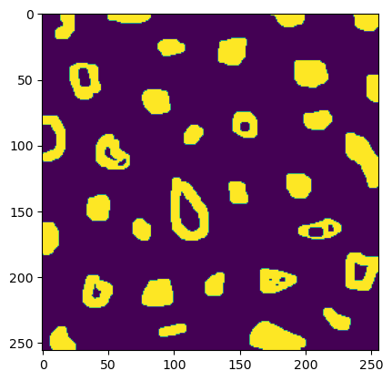

```python
img = cv2.imread('bolhas.png', cv2.IMREAD_GRAYSCALE)

#cv2.imshow('Bolhas', img)
cv2.waitKey()
cv2.destroyAllWindows()
plt.imshow(img)

alt, larg = img.shape
print('Altura:', alt,', Largura:',larg)
```

Agora, realizamos a varredura nas bordas, juntamente com a aplicação do *floodfill*.

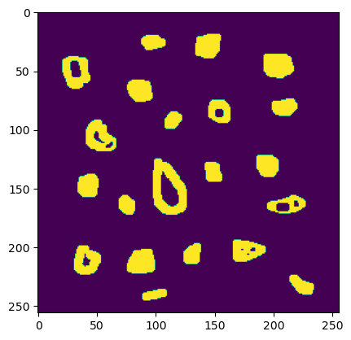

```python
img_aux = img.copy()
elementos = 0

# Eliminando bolhas que tocam as bordas, transformando-as em plano de fundo
for i in range(alt):
    if img_aux[i,0] == 255:
        cv2.floodFill(img_aux, None, (0,i), 0)
        elementos += 1
    if img_aux[i,larg-1] == 255:
        cv2.floodFill(img_aux, None, (larg-1,i), 0)
        elementos += 1

for j in range(larg):
    if img_aux[0,j] == 255:
        cv2.floodFill(img_aux, None, (j,0), 0)
        elementos += 1
    if img_aux[alt-1,j] == 255:
        cv2.floodFill(img_aux, None, (j,alt-1), 0)
        elementos += 1

#cv2.imshow('Sem bolhas nas bordas', img_aux)
cv2.waitKey()
cv2.destroyAllWindows()

plt.imshow(img_aux)
```

Agora que os elementos que tocam as bordas foram removidos, podemos iniciar a contagem de bolhas da imagem através do algoritmo *labeling*. Para isso, repetimos o processo de varredura para encontrar as bolhas, porém dessa vez ao encontra-las, o *floodFill* será utilizado para preenche-las com um tom de cinza de numeração igual a contagem de bolhas, para termos uma coleção de bolhas com tonalidades diferentes.

```
Bolhas: 21
```

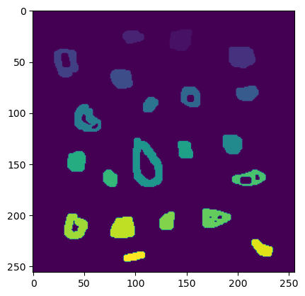

```python
bolhas = 0

for i in range(alt):
    for j in range(larg):
      if img_aux[i,j] == 255:
        bolhas += 1
        cv2.floodFill(img_aux, None, (j,i), bolhas)

print('Bolhas: {}'.format(bolhas))

#cv2.imshow('Contagem de bolhas', img_aux)
cv2.waitKey()
cv2.destroyAllWindows()

plt.imshow(img_aux)
```

Por fim, podemos realizar a contagem de bolhas com buracos. Para isso, utilizamos a função *floodFill* para transformar o fundo da imagem em tom de cinza 255 (branco). Desta forma, os buracos presentes nas bolhas continuam pretos, resultando na seguinte imagem:

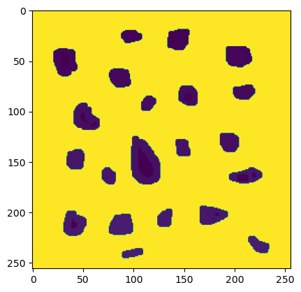

```python
cv2.floodFill(img_aux, None, (0,0), 255)

#cv2.imshow('Fundo branco', img_aux)
cv2.waitKey()
cv2.destroyAllWindows()

plt.imshow(img_aux)
```

Em seguida, realizamos novamente a varredura aplicando o *floodFill* para que os buracos sejam preenchidos com branco, assim como o fundo da imagem. Dessa forma, a cada aplicação é realizada a contagem do buraco, resultando na contagem de bolhas com buracos.

```python
num_bolhas_buracos = 0

for i in range(1, alt):
    for j in range(1, larg):
        if img_aux[i,j] == 0:
            cv2.floodFill(img_aux, None, (j,i), 255)
            if img_aux[i,j-1] != 220:
                cv2.floodFill(img_aux, None, (j-1,i), 220)
                num_bolhas_buracos += 1

print(f'A figura tem {num_bolhas_buracos} bolhas com buracos')
```

```
A figura tem 7 bolhas com buracos
```